# Logistic Regression

Catherine Cao and Dustin VanStee

September 19, 2016

> Have you ever wanted predict outcomes of NBA games in real time as the games are occurring? This webpage is part 2 or a 2 part series that will describe the methods you can use to build your own prediction model. We will leverage IBM’s Data Science Experience environment with Rstudio to build linear and logistic regression models using R and Spark.

[figure not shown]

datascience.ibm.com

> This webpage shows how to perform logistic regression on the prepared NBA data frame to build a model that will help make in game predictions about which team is most likely to win.

> This site holds the live hosted website running the models from the analysis http://169.55.24.28:6001/

> All the source for this demo including the HOWTO is located on GitHub. https://github.com/dustinvanstee/nba-rt-prediction

# Imports

```r
#install.packages("dplyr")
#install.packages("reshape2")
#install.packages("ggplot2")
#install.packages("RCurl")

library(dplyr)
library("reshape2")
library("ggplot2")
library(RCurl)
```

# Read In CSV File For Logistic Regression

> Read data from part1. Data preloaded into Github

```r
logisticDF <- read.csv("https://raw.githubusercontent.com/dustinvanstee/nba-rt-prediction/master/DSX_NBA_Demo_in_R/nba-datawrangle-lrDF.csv",header=TRUE,sep=",")

logisticDF$cf3 <- logisticDF$pct_left * logisticDF$teambspread / 100
logisticDF$cf4 <- logisticDF$scoreb_scorea ^ 3
```

# Inspect the Data

> Print out a summary of the dataframe to make sure the data is loaded properly.

```r
# There are approximately 13000 data points
summary(logisticDF)
```

```
##        X                         key           fscorea          fscoreb      fscorea_fscoreb  fscoreb_fscorea     away_win        home_win      teamaspread        overunder      teambspread      teama_vegas_fscore teamb_vegas_fscore     scorea           scoreb          timeleft         teama     …
##  Min.   :    1   2016-04-08.mil.bos:  318   Min.   : 68.00   Min.   : 80.0   Min.   :-38.00   Min.   :-29.00   Min.   :0.000   Min.   :0.000   Min.   :-13.000   Min.   :180.5   Min.   :-19.000   Min.   : 84.38     Min.   : 84.92     Min.   :  0.00   Min.   :  0.00   Min.   : 0.00   cha    : 796  …
##  1st Qu.: 3305   2016-04-10.orl.mia:  282   1st Qu.: 92.00   1st Qu.: 97.0   1st Qu.:-15.00   1st Qu.: -5.00   1st Qu.:0.000   1st Qu.:0.000   1st Qu.: -3.500   1st Qu.:200.3   1st Qu.: -9.500   1st Qu.: 97.17     1st Qu.:100.50     1st Qu.: 28.00   1st Qu.: 29.00   1st Qu.:10.07   san    : 716  …
##  Median : 6609   2016-04-05.pho.atl:  163   Median : 99.00   Median :105.0   Median : -8.00   Median :  8.00   Median :0.000   Median :1.000   Median :  4.833   Median :205.5   Median : -4.833   Median :100.25     Median :104.50     Median : 53.00   Median : 56.00   Median :22.73   okc    : 671  …
##  Mean   : 6609   2016-04-13.atl.wsh:  162   Mean   : 99.71   Mean   :105.3   Mean   : -5.59   Mean   :  5.59   Mean   :0.353   Mean   :0.647   Mean   :  3.518   Mean   :204.8   Mean   : -3.518   Mean   :100.66     Mean   :104.18     Mean   : 52.85   Mean   : 56.14   Mean   :22.40   cle    : 639  …
##  3rd Qu.: 9913   2016-04-05.cle.mil:  158   3rd Qu.:107.00   3rd Qu.:113.0   3rd Qu.:  5.00   3rd Qu.: 15.00   3rd Qu.:1.000   3rd Qu.:1.000   3rd Qu.:  9.500   3rd Qu.:209.5   3rd Qu.:  3.500   3rd Qu.:103.50     3rd Qu.:108.75     3rd Qu.: 77.00   3rd Qu.: 82.00   3rd Qu.:34.25   tor    : 578  …
##  Max.   :13217   2016-04-08.mem.dal:  158   Max.   :131.00   Max.   :144.0   Max.   : 29.00   Max.   : 38.00   Max.   :1.000   Max.   :1.000   Max.   : 19.000   Max.   :225.2   Max.   : 13.000   Max.   :115.75     Max.   :119.12     Max.   :131.00   Max.   :144.00   Max.   :48.00   mem    : 577  …
##                  (Other)           :11976                                                                                                                                                                                                                                                  (Other):9240  …
```

# Function to Create the Model and Train it and Test it

> Since there are multiple models to be trained, use this function to partition the data into training and test data sets. This function will return a number of objects. It returns the per quarter error rates, prediction dataframe, test data, and the model.

```r
trainAndTest <- function(data, features){
  cat("*************************************************", collapse = "\n")

  # Split the data into training and test sets
  set.seed(1)
  train <- sample_frac(data, 0.7)
  test <- data[-as.numeric(rownames(train)),]
  cat("Training Samples = ", nrow(train) , collapse = "\n")
  cat("Test Samples = ", nrow(test), collapse = "\n")

# standardize the data
  train_features <- as.data.frame(scale(train[names(train) %in% features]))
  test_features <- as.data.frame(scale(test[names(test) %in% features]))

# add pct_complete since we will need it when compute f1 score for 4 quarters.
    pct_complete <- train$pct_complete
    train_features <- cbind(train_features, pct_complete)
    pct_complete <- test$pct_complete
    test_features <- cbind(test_features, pct_complete)

# fit the model
  model <- glm(train$home_win ~ . - pct_complete , data = train_features, family = "binomial")
  cat("lrModel.intercept = ", model$coefficients[1], collapse = "\n")
  cat("lrModel.weights = ", model$coefficients[-1], collapse = "\n")

# Generate Predictions
 train_prob <- predict(model, newdata = train_features, type = "response")
 train_fitted <- ifelse(train_prob > .5, 1, 0)
 correct <- ifelse(train_fitted == train$home_win, 1, 0)
 pct_comp_ceil <- ceiling(train$pct_complete)
 trn_predictions <- data.frame(correct, pct_comp_ceil, train_prob)

 test_prob <- predict(model, newdata = test_features, type = "response")
 test_fitted <- ifelse(test_prob > .5, 1, 0)
 correct2 <- ifelse(test_fitted == test$home_win, 1, 0)
 pct_comp_ceil2 <- ceiling(test$pct_complete)
 predictions2 <- data.frame(correct2, pct_comp_ceil2, test_prob)


# Evaluate predictions and Print results
 evaluator <- function(act, pred, data){
    cm <- as.matrix(table(act, pred))
    diag = diag(cm)
    rowsums = apply(cm, 1, sum)
    colsums = apply(cm, 2, sum)
    precision = diag / colsums
    recall = diag / rowsums
    f1 = 2 * precision[2] * recall[2] / (precision[2] + recall[2])
    return(f1)
 }


 trn_tot_f1 <- evaluator(train$home_win, train_fitted)
 tst_tot_f1 <- evaluator(test$home_win, test_fitted)

 Quater_f1 <- function(start, end){
  Q <- subset(test_features, test_features$pct_complete >= start & test_features$pct_complete < end)
  Q_prob <- predict(model, newdata = Q, type = "response")
  Q_fitted <- ifelse(Q_prob > .5, 1, 0)
  Q_actual <- subset(test$home_win, test$pct_complete >= start & test$pct_complete < end)
  f1 <- evaluator(Q_actual, Q_fitted)
  return(f1)
}

 f1q1 <- Quater_f1(0, 25)
 f1q2 <- Quater_f1(25, 50)
 f1q3 <- Quater_f1(50, 75)
 f1q4 <- Quater_f1(75, 100)

 cat("Total Train f1 = ", trn_tot_f1, collapse = "\n")
 cat("Total Test f1 = ", tst_tot_f1, collapse = "\n")

 cat("Q1 Test f1 = ", f1q1, collapse = "\n")
 cat("Q2 Test f1 = ", f1q2, collapse = "\n")
 cat("Q3 Test f1 = ", f1q3, collapse = "\n")
 cat("Q4 Test f1 = ", f1q4, collapse = "\n")

 qs <- c(f1q1, f1q2, f1q3, f1q4, tst_tot_f1)


 invisible(list(qs, predictions2, test, model))

}
```

# Test and Train multiple models

```r
# Evaluate 3 different Models

f1m0 <- trainAndTest(logisticDF, c("scoreb_scorea"))
```

```
## Training Samples =  9252
## Test Samples =  3965
## lrModel.intercept =  1.002115
## lrModel.weights =  2.151302
## Total Train f1 =  0.8445149
## Total Test f1 =  0.844957
## Q1 Test f1 =  0.7608696
## Q2 Test f1 =  0.8064734
## Q3 Test f1 =  0.8606811
## Q4 Test f1 =  0.9353718
```

```r
f1m1 <- trainAndTest(logisticDF, c("scoreb_scorea", "teamaspread"))
```

```
## Training Samples =  9252
## Test Samples =  3965
## lrModel.intercept =  1.098221
## lrModel.weights =  0.8798637 1.898588
## Total Train f1 =  0.8643723
## Total Test f1 =  0.8745981
## Q1 Test f1 =  0.806338
## Q2 Test f1 =  0.8448519
## Q3 Test f1 =  0.9002357
## Q4 Test f1 =  0.9331437
```

```r
f1m2 <- trainAndTest(logisticDF, c("scoreb_scorea", "teamaspread", "cf1", "cf2", "cf3"))
```

```
## Training Samples =  9252
## Test Samples =  3965
## lrModel.intercept =  1.812254
## lrModel.weights =  0.1926325 -1.390526 10.25754 -0.8349576 -0.6840641
## Total Train f1 =  0.8730029
## Total Test f1 =  0.8785647
## Q1 Test f1 =  0.8125545
## Q2 Test f1 =  0.8515679
## Q3 Test f1 =  0.8916996
## Q4 Test f1 =  0.9441261
```

# Examine F1 scores from the models

> F1 score is a metric used to evaluate different models it runs on a scale from 0 to 1 with the larger value meaning the model performs better. F1 score is a combination of precision/recall and helps in situations where outcomes are highly skewed in one direction. eg 95% samples are wins, 5% are losses. In that example, a model that blindly predicts a win every time would be 95% correct… F1 adjusts for this fact and would penalize for the false negatives.

```r
# Build a small dataframe to hold my F1 scores.

model <- c("model0", "model1", "model2")
errDF <- cbind(as.data.frame(rbind(f1m0[[1]], f1m1[[1]], f1m2[[1]])), model)
colnames(errDF) <- c("Q1", "Q2", "Q3", "Q4", "total", "model")

head(errDF)
```

```
##          Q1        Q2        Q3        Q4     total  model
## 1 0.7608696 0.8064734 0.8606811 0.9353718 0.8449570 model0
## 2 0.8063380 0.8448519 0.9002357 0.9331437 0.8745981 model1
## 3 0.8125545 0.8515679 0.8916996 0.9441261 0.8785647 model2
```

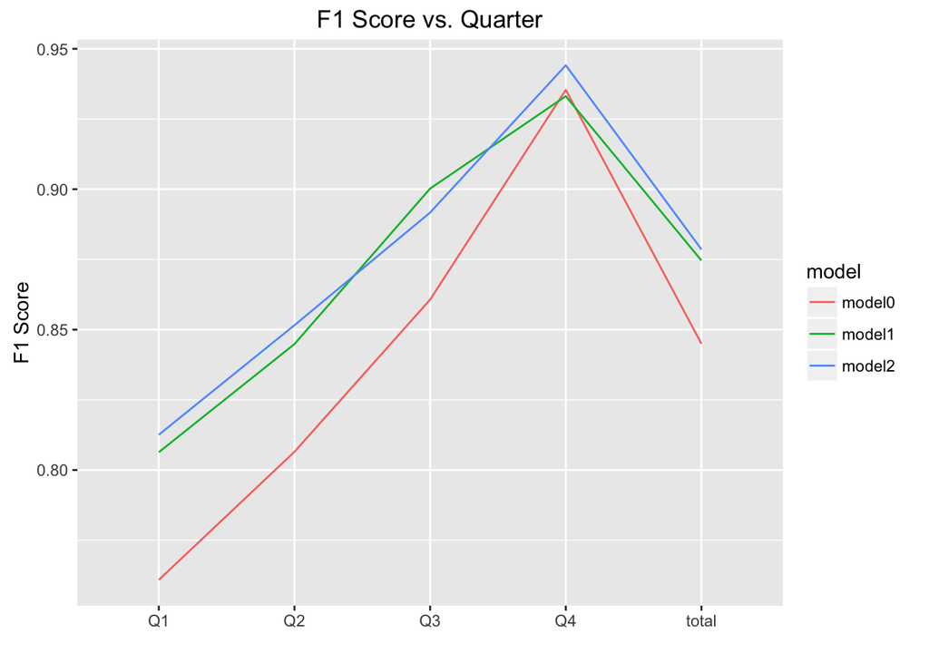

```r
# plot
# convert to long format
errDF_long <- melt(errDF, id = "model")
# Note, I had to enable Arial fonts if running locally on Mac OSX
ggplot(data = errDF_long,
       aes(x = variable, y = value , group = model, colour = model)) +
       geom_line() +
       xlab("") +
       ylab("F1 Score") +
       ggtitle("F1 Score vs. Quarter")
```

```r
#Going from model0 to model1 yields a decent improvement, but after that the improvement is marginally better with the extra terms
```

# Lets take a look at some of the Errors to see if there is any pattern

```r
predictions_2 <- as.data.frame(f1m0[2])
test <- as.data.frame(f1m0[3])

error_check <- data.frame(predictions_2, test[c("teama", "scorea", "teamb", "scoreb", "timeleft", "teamaspread",'fscorea', 'fscoreb', "home_win", "fscoreb_fscorea")])

error_check_false1 <- filter(error_check, correct2 == 0 & fscoreb_fscorea < 4 & fscoreb_fscorea > -4)
head(error_check_false1, n = 20)
```

```
##    correct2 pct_comp_ceil2 test_prob teama scorea teamb scoreb   timeleft teamaspread fscorea fscoreb home_win fscoreb_fscorea
## 1         0             89 0.5080335   san     76   uta     74  5.6166667        -3.5      88      86        0              -2
## 2         0             94 0.5080335   san     80   uta     78  2.8833333        -3.5      88      86        0              -2
## 3         0             91 0.5080335   san     78   uta     76  4.4000000        -3.5      88      86        0              -2
## 4         0              0 0.5978573   san      0   uta      0 48.0000000        -3.5      88      86        0              -2
## 5         0             96 0.5978573   san     80   uta     80  2.1500000        -3.5      88      86        0              -2
## 6         0             63 0.5080335   san     51   uta     49 17.9333333        -3.5      88      86        0              -2
## 7         0             42 0.5080335   san     35   uta     33 28.1166667        -3.5      88      86        0              -2
## 8         0             63 0.5533810   san     50   uta     49 17.9333333        -3.5      88      86        0              -2
## 9         0             41 0.5080335   san     35   uta     33 28.5500000        -3.5      88      86        0              -2
## 10        0             99 0.5080335   san     86   uta     84  0.6166667        -3.5      88      86        0              -2
## 11        0             20 0.5978573   san     18   uta     18 38.5500000        -3.5      88      86        0              -2
## 12        0             12 0.5978573   san     10   uta     10 42.6166667        -3.5      88      86        0              -2
## 13        0             24 0.3325488   hou     22   dal     16 36.4833333        -1.0      86      88        1               2
## 14        0             79 0.4176881   hou     77   dal     73 10.4833333        -1.0      86      88        1               2
## 15        0             18 0.3741450   hou     18   dal     13 39.7000000        -1.0      86      88        1               2
## 16        0             23 0.4176881   hou     20   dal     16 37.2500000        -1.0      86      88        1               2
## 17        0             76 0.4176881   hou     74   dal     70 11.6166667        -1.0      86      88        1               2
## 18        0             10 0.3325488   hou     14   dal      8 43.3000000        -1.0      86      88        1               2
## 19        0             78 0.4176881   hou     77   dal     73 10.7500000        -1.0      86      88        1               2
## 20        0             22 0.4176881   hou     20   dal     16 37.7833333        -1.0      86      88        1               2
```

```r
error_check_false2 <- filter(error_check, fscoreb_fscorea < 4 & fscoreb_fscorea > -4)
head(error_check_false2, n = 20)
```

```
##    correct2 pct_comp_ceil2 test_prob teama scorea teamb scoreb  timeleft teamaspread fscorea fscoreb home_win fscoreb_fscorea
## 1         1             71 0.1669082   san     62   uta     51 14.000000        -3.5      88      86        0              -2
## 2         1             52 0.3741450   san     43   uta     38 23.483333        -3.5      88      86        0              -2
## 3         1             35 0.2238635   san     31   uta     22 31.550000        -3.5      88      86        0              -2
## 4         0             89 0.5080335   san     76   uta     74  5.616667        -3.5      88      86        0              -2
## 5         0             94 0.5080335   san     80   uta     78  2.883333        -3.5      88      86        0              -2
## 6         1             32 0.1669082   san     31   uta     20 32.750000        -3.5      88      86        0              -2
## 7         0             91 0.5080335   san     78   uta     76  4.400000        -3.5      88      86        0              -2
## 8         0              0 0.5978573   san      0   uta      0 48.000000        -3.5      88      86        0              -2
## 9         0             96 0.5978573   san     80   uta     80  2.150000        -3.5      88      86        0              -2
## 10        1             58 0.3741450   san     46   uta     41 20.366667        -3.5      88      86        0              -2
## 11        1             73 0.1669082   san     64   uta     53 13.116667        -3.5      88      86        0              -2
## 12        1             56 0.2571016   san     46   uta     38 21.550000        -3.5      88      86        0              -2
## 13        1             64 0.4625534   san     52   uta     49 17.550000        -3.5      88      86        0              -2
## 14        0             63 0.5080335   san     51   uta     49 17.933333        -3.5      88      86        0              -2
## 15        1             64 0.4176881   san     53   uta     49 17.433333        -3.5      88      86        0              -2
## 16        0             42 0.5080335   san     35   uta     33 28.116667        -3.5      88      86        0              -2
## 17        0             63 0.5533810   san     50   uta     49 17.933333        -3.5      88      86        0              -2
## 18        1             37 0.1938014   san     35   uta     25 30.366667        -3.5      88      86        0              -2
## 19        1             80 0.2571016   san     69   uta     61 10.033333        -3.5      88      86        0              -2
## 20        1             68 0.4176881   san     55   uta     51 15.816667        -3.5      88      86        0              -2
```

```r
# f1m3 <- trainAndTest(logisticDF, c("scoreb-scorea",  "teamaspread", "cf1", "cf2", "cf3","cf4" ))

# Some errors due to
# early in game ....
# close scores at the end
# some games the spread strongly effects game at the end... mabye scale that somehow by time left ?
# teams that had an early lead, even though not favored did end up winning.  maybe add a scorediff^2
```

# Logistic Analysis And Explanation

> Complex Model 2 DiscussionWhen the logistic regression model is trained, the weights corresponding to each feature are optimized to minimize the error of the predictions. Below are the weights from the final model that was trained with 5 features.

```r
print(f1m2[[4]]$coefficients[-1])
```

```
##   teamaspread scoreb_scorea           cf1           cf2           cf3
##     0.1926325    -1.3905259    10.2575355    -0.8349576    -0.6840641
```

Interpretting weights can be tricky, especially if input features are functions of each other (ie, if one feature changes, it implies another feature changes)

# Next Steps

> This is the end of the model building portion of the analysis. The next step for this analysis was to implement a prediction service and a web page that made use of the service. The HOWTO documents the steps and some details regarding how to deploy the app. For a live look at the app, see this site … http://169.55.24.28:6001/